# Police Abuse Database

*159 incidents from 118 departments affecting 243 people.*

The police abuse database attempts to collect statistics about clear cases of police abusing their position in ways that violate the rights of the public. The information is sourced from publicly-disclosed articles that are reported in the news. The database is limited to instances of police abuse in the United States. If you’re interested in auditing the findings or doing your own analysis of the incidents you can download the raw data here: https://github.com/police-abuse/padb-data

# Database Composition

At this time, the database is made up of 159 incidents collected from public articles.

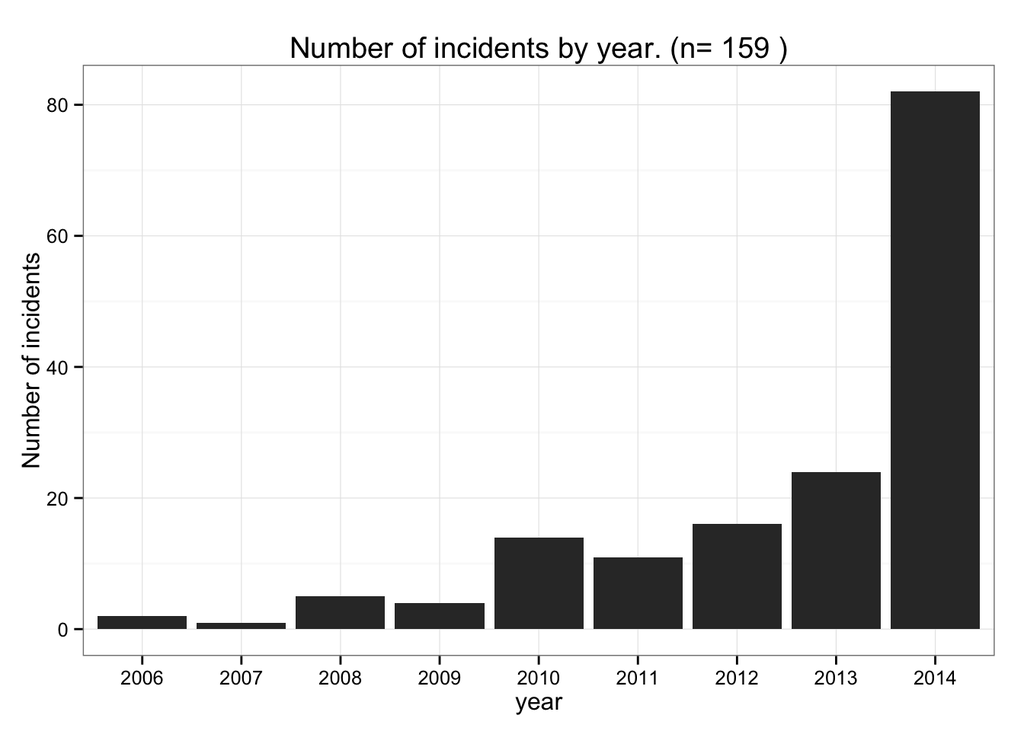

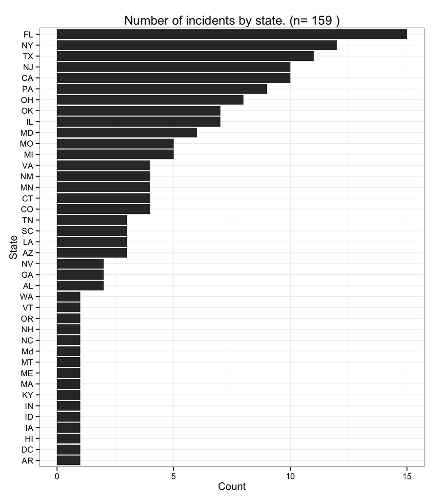

# Who gets abused

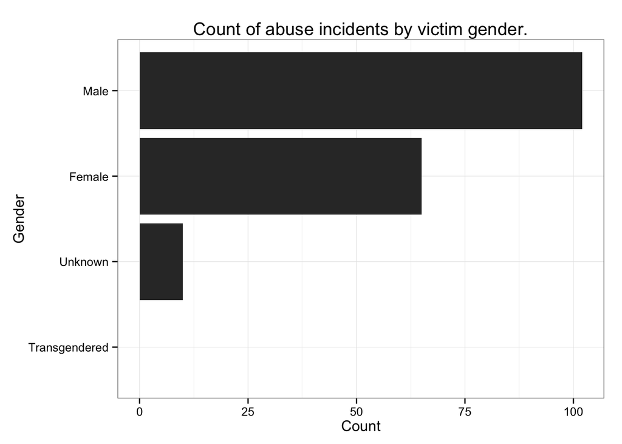

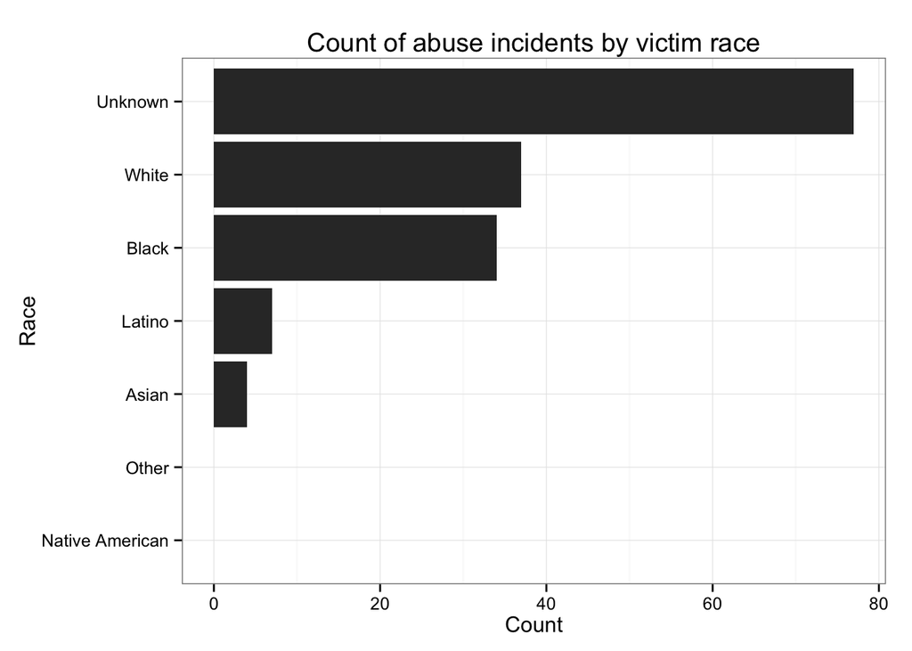

There are a couple interesting things to note here. First of all, news outlets often do not report the specific information of the victim of an incident. So a very large number of incidents have an unknown race or unknown gender. When possible the information has been gleaned from a video of the incident, but very often there is no record. Of the remaining incidents where the race of at least one victim is known, we see more incidents involving white victims than black victims. **Be careful how you interpret this!** First of all, this sample size is not very large and the number of incidents with black victims and the number with white victims is very close. The true population could very easily be the reverse of what is shown here. Also, keep in mind that white people make up a much larger percentage of the population in the United States. So if police abuse was evenly distributed among the population we should expect to see white victims in 122 rather than the 37 currently observed.

Here is another plot of the race of the victims compared to what would be expected if incidents of police abuse were equally distributed among the population. The expected values are based on the proportion of the population given by the [US Census Bureau](http://quickfacts.census.gov/qfd/states/00000.html)

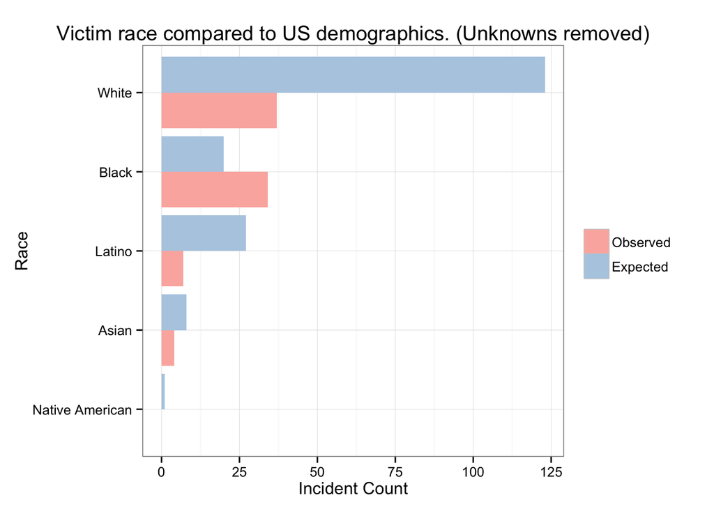

# Who does the abusing

| Department name | Number of incidents |
| --- | --- |
| New York Police Department | 7 |
| Atlantic City Police Department | 4 |
| City of Pittsburgh Bureau of Police | 4 |
| Newton Police Department | 4 |
| Oklahoma Highway Patrol | 4 |

Obviously as the number of incidents in the dataset grows this table will become more interesting. One interesting fact already in the table is that all of the incidents for the Atlantic City Police Department involved the [the same officer.](http://reason.com/blog/2013/11/22/15-internal-affairs-investigations-in-tw).

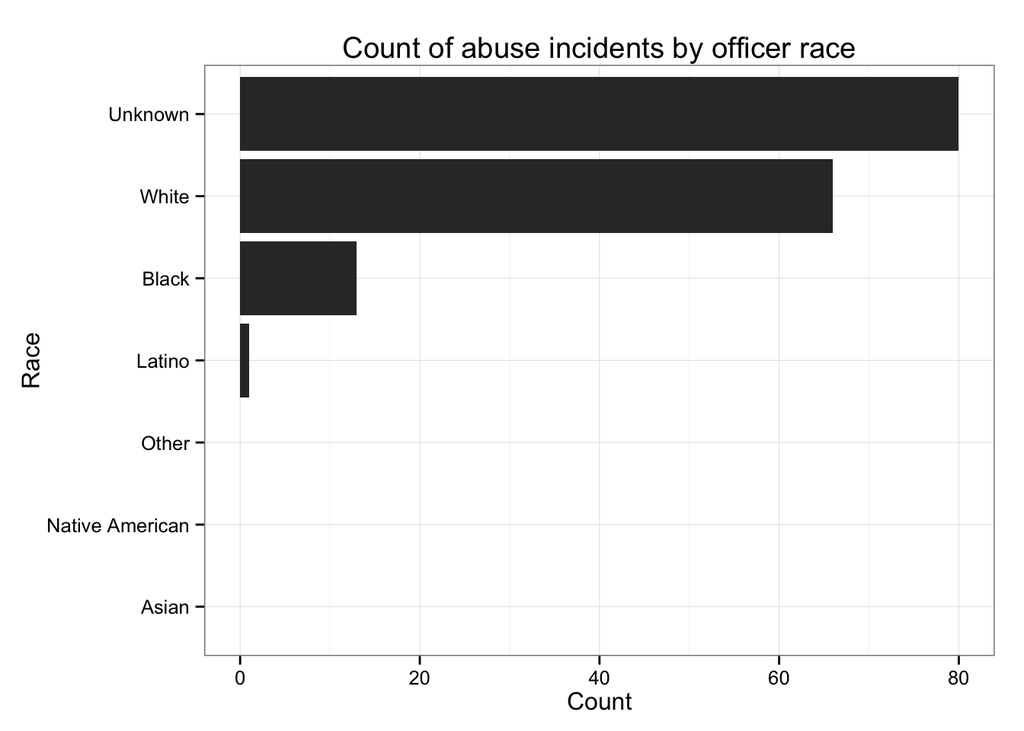

> Why isn’t there a comparison of officer race to the expected number of incidents for the population? The racial makeup of law enforcement officers may not match the racial makeup of the United States. So it isn’t valid to say that 77% of police abuse incidents should be expected to involve a white officer unless there is some evidence that 77% **of police officers** are white.

# What kind of abuse are we talking?

- Abuse of force: using a weapon or inflicting pain on someone when it is not necessary
- Improper search: searching a person without cause or warrant
- General misconduct: includes falsifying reports, theft, testilying, and false arrest.
- Intimidation: verbal abuse, threats, and excessive show of force (for example, unnecessary SWAT team deployment)
- Sexual conduct: Anything sexual.

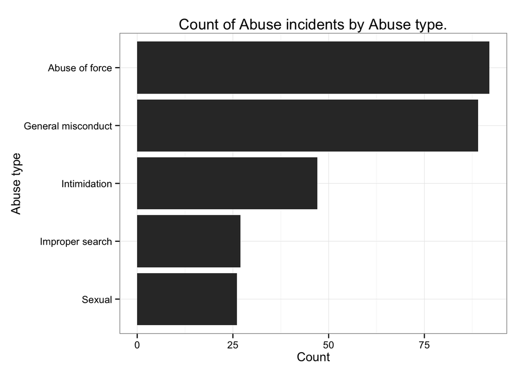

**That looks like it adds up to more than 159 incidents!** Yes is probably does. The reason is because there are relatively few incidents where there is only one type of abuse. When an officer beats someone up (Abuse of force) he or she almost always arrests the person for resisting or disorderly conduct (General misconduct).